# Combined_Codes

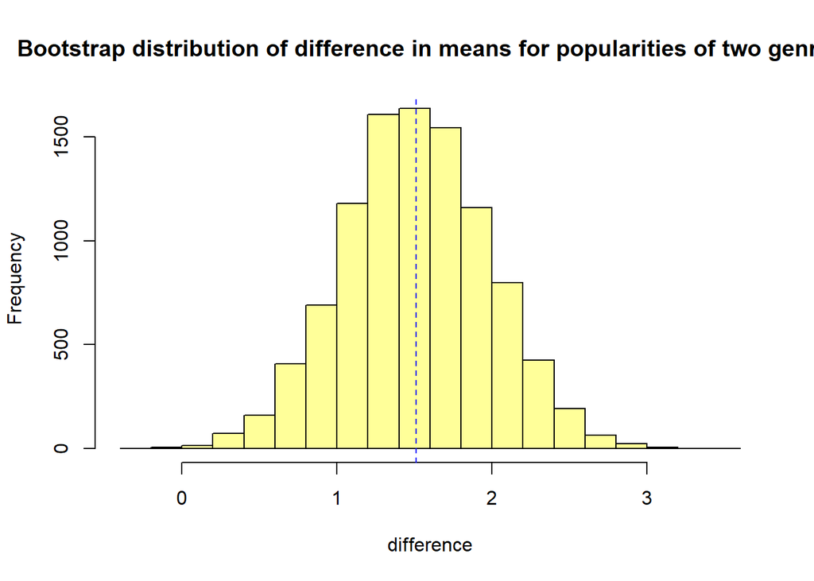

```r
hist(difference, main = "Bootstrap distribution of difference in means for popularities of two genres",col = '#FFFF99')
abline(v = mean(ur_pop) - mean(dt_pop), col = "blue", lty = 2)
```

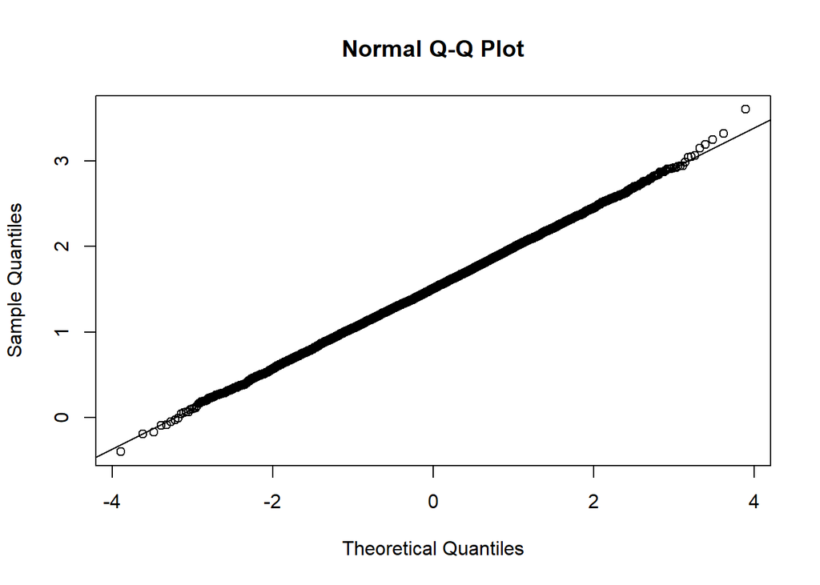

```r
qqnorm(difference)
qqline(difference)
```

```r
# 95% CI
CI <- quantile(difference, c(0.025, 0.975))
CI
```

```
##      2.5%     97.5%
## 0.5916207 2.4320700
```

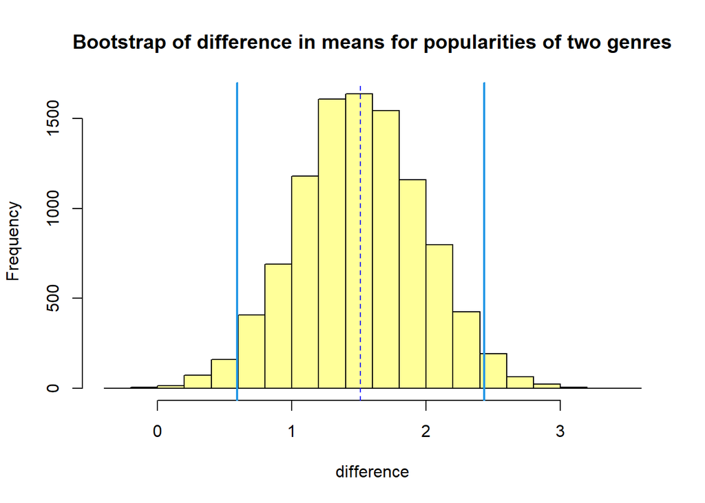

```r
hist(difference, main = "Bootstrap of difference in means for popularities of two genres",col = '#FFFF99')
abline(v = mean(ur_pop) - mean(dt_pop), col = "blue", lty = 2)
abline(v = CI, col = 4, lwd = 2)
```

Import the cleaned dataset

```r
df <- read.csv("spotify_cleaned.csv")
head(df,5)
```

```
##   X                                                  name           artist
## 1 1 I Don't Care (with Justin Bieber) - Loud Luxury Remix       Ed Sheeran
## 2 2                       Memories - Dillon Francis Remix         Maroon 5
## 3 3                       All the Time - Don Diablo Remix     Zara Larsson
## 4 4                     Call You Mine - Keanu Silva Remix The Chainsmokers
## 5 5               Someone You Loved - Future Humans Remix    Lewis Capaldi
##   popularity year genre  subgenre danceability energy key loudness mode
## 1         66 2019   pop dance pop        0.748  0.916   6   -2.634    1
## 2         67 2019   pop dance pop        0.726  0.815  11   -4.969    1
## 3         70 2019   pop dance pop        0.675  0.931   1   -3.432    0
## 4         60 2019   pop dance pop        0.718  0.930   7   -3.778    1
## 5         69 2019   pop dance pop        0.650  0.833   1   -4.672    1
##   speechiness acousticness instrumantalness liveness valence   tempo duration
## 1      0.0583       0.1020         0.00e+00   0.0653   0.518 122.036   194754
## 2      0.0373       0.0724         4.21e-03   0.3570   0.693  99.972   162600
## 3      0.0742       0.0794         2.33e-05   0.1100   0.613 124.008   176616
## 4      0.1020       0.0287         9.43e-06   0.2040   0.277 121.956   169093
## 5      0.0359       0.0803         0.00e+00   0.0833   0.725 123.976   189052
```

From the daily observations, some music genres do dominate the front rank of the listener’s music charts, such as pop music. There are many reasons for this phenomenon, such as the fact that these pop music are sung by favorite singers. Hence, with this complex relationship, whether the popularity of music is related to the genre of music itself needs to be studied. In the previous hypothesis test, the relationship between the average populative of rock music and of rap music has been addressed. However, the general relationship between the genres and the popularity cannot be explained by a test between two specific genres of musics.

In the second hypothsis test, whether the popularity is related to the genre will be examinated. Before implementing the test method, categorizing the popularity into three different groups - high,medium,low - will be helpful in understanding the relationship. Based on the 0 to 100 popularity score rules on spotify, three categories can be presented as: - High: popularity >= 66 - medium: 33 > popularity > 66 - low: popularity <= 33

The two-way table is generated to show the frequency of songs in the group of genre and popularity.

```r
df$popularity <- as.factor(ifelse(df$popularity>=66, 'High',
                     ifelse(df$popularity<66 & df$popularity>33, 'Medium','Low')))
```

```r
library(knitr)
t1 = table(df$popularity,df$genre)
kable(t1,align = "lccrr")
```

|  | edm | latin | pop | r&b | rap | rock |
| --- | --- | --- | --- | --- | --- | --- |
| High | 613 | 1378 | 1603 | 1096 | 921 | 1000 |
| Low | 2733 | 1343 | 1533 | 2043 | 1654 | 1748 |
| Medium | 2697 | 2432 | 2371 | 2292 | 3168 | 2203 |

In statistics, Chi-square test is commonly used in testing the independence of two variables. If two variables are independent, it means there is no relationship between two factors. Based on the question of whether the popularity is related to the genre, the null hypothesis (H0) can be set as the popularity and the genre is independent, and then correspondingly, the alternative hypothesis (Ha) will be the popularity and the genre is dependent.In this case, the specific hypotheses are:

- H0: There is no relationship between the popularity and the genre of musics.
- Ha: There is relationship between the popularity and the genre of musics.

```r
t2 <- chisq.test(t1)
t2
```

```
##
##  Pearson's Chi-squared test
##
## data:  t1
## X-squared = 1270.6, df = 10, p-value < 2.2e-16
```

```r
chisq.test(t1)$expected
```

```
##
##               edm    latin      pop      r&b      rap      rock
##   High   1216.957 1037.726 1109.016 1093.711 1156.542  997.0471
##   Low    2034.828 1735.143 1854.343 1828.752 1933.810 1667.1242
##   Medium 2791.215 2380.131 2543.641 2508.537 2652.647 2286.8287
```

From the output, the p-value is less than the significance level of 5%, which means the rejection of null hypothesis. In this context, rejecting the null hypothesis for the Chi-square test of independence means there is a significant relationship between the popularity and the genre of musics.

Load the required dataset

```r
artists <- read.csv("./Tracks_Artists.csv")
head(artists)
```

```
##   X  artist_name Valence danceability energy loudness speechiness acousticness
## 1 1 Taylor Swift  0.0984        0.735  0.444  -10.519      0.0684       0.2040
## 2 2 Taylor Swift  0.0382        0.658  0.378   -8.300      0.0379       0.0593
## 3 3 Taylor Swift  0.5190        0.638  0.634   -6.582      0.0457       0.1330
## 4 4 Taylor Swift  0.1540        0.659  0.323  -13.425      0.0436       0.7350
## 5 5 Taylor Swift  0.3760        0.694  0.380  -10.307      0.0614       0.4160
## 6 6 Taylor Swift  0.2300        0.636  0.377  -11.721      0.0708       0.7100
##   liveness   tempo                             track_name
## 1   0.1700  97.038                          Lavender Haze
## 2   0.0976 108.034                                 Maroon
## 3   0.1520  96.953                              Anti-Hero
## 4   0.1160 110.007 Snow On The Beach (feat. Lana Del Rey)
## 5   0.1260 120.044                You're On Your Own, Kid
## 6   0.1150 139.966                          Midnight Rain
##                album_name album_release_year
## 1 Midnights (3am Edition)               2022
## 2 Midnights (3am Edition)               2022
## 3 Midnights (3am Edition)               2022
## 4 Midnights (3am Edition)               2022
## 5 Midnights (3am Edition)               2022
## 6 Midnights (3am Edition)               2022
```

```r
summary(artists$album_release_year)
```

```
##    Min. 1st Qu.  Median    Mean 3rd Qu.    Max.
##    1999    2008    2012    2013    2018    2022
```

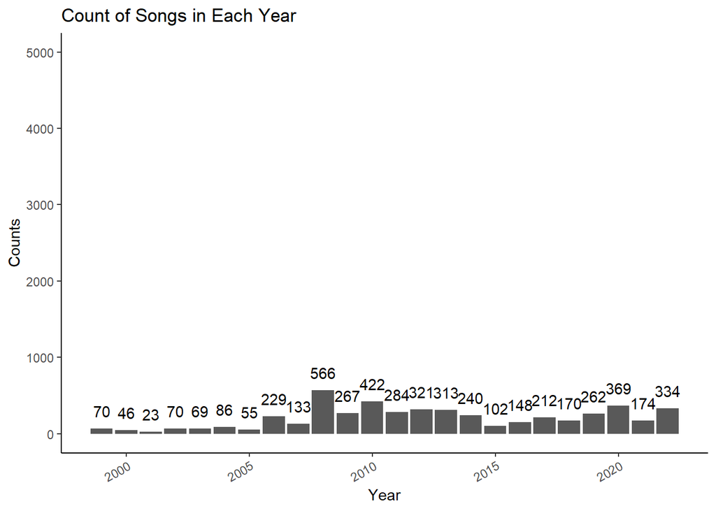

```r
library(ggplot2)
ggplot(artists, aes(x=album_release_year)) +
  geom_bar()+
  geom_text(stat='count', aes(label=..count..), vjust=-1)+
  ylim(0,5000)+
  theme_classic()+
  theme(axis.text.x=element_text(angle=30,hjust=1))+
  labs(title="Count of Songs in Each Year",
        x ="Year", y = "Counts")
```

```r
artists$year_range <- ifelse(artists$album_release_year < 2011, "1999-2010","2011-2022")
head(artists)
```

```
##   X  artist_name Valence danceability energy loudness speechiness acousticness
## 1 1 Taylor Swift  0.0984        0.735  0.444  -10.519      0.0684       0.2040
## 2 2 Taylor Swift  0.0382        0.658  0.378   -8.300      0.0379       0.0593
## 3 3 Taylor Swift  0.5190        0.638  0.634   -6.582      0.0457       0.1330
## 4 4 Taylor Swift  0.1540        0.659  0.323  -13.425      0.0436       0.7350
## 5 5 Taylor Swift  0.3760        0.694  0.380  -10.307      0.0614       0.4160
## 6 6 Taylor Swift  0.2300        0.636  0.377  -11.721      0.0708       0.7100
##   liveness   tempo                             track_name
## 1   0.1700  97.038                          Lavender Haze
## 2   0.0976 108.034                                 Maroon
## 3   0.1520  96.953                              Anti-Hero
## 4   0.1160 110.007 Snow On The Beach (feat. Lana Del Rey)
## 5   0.1260 120.044                You're On Your Own, Kid
## 6   0.1150 139.966                          Midnight Rain
##                album_name album_release_year year_range
## 1 Midnights (3am Edition)               2022  2011-2022
## 2 Midnights (3am Edition)               2022  2011-2022
## 3 Midnights (3am Edition)               2022  2011-2022
## 4 Midnights (3am Edition)               2022  2011-2022
## 5 Midnights (3am Edition)               2022  2011-2022
## 6 Midnights (3am Edition)               2022  2011-2022
```

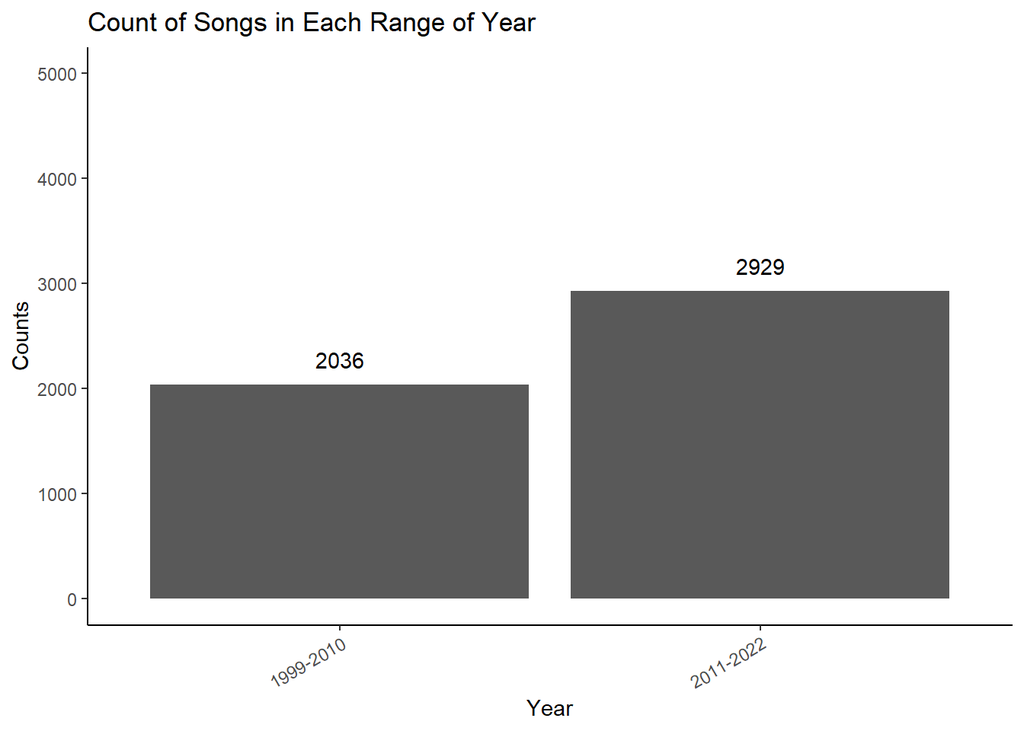

```r
library(ggplot2)
ggplot(artists, aes(x=year_range)) +
  geom_bar()+
  geom_text(stat='count', aes(label=..count..), vjust=-1)+
  ylim(0,5000)+
  theme_classic()+
  theme(axis.text.x=element_text(angle=30,hjust=1))+
  labs(title="Count of Songs in Each Range of Year",
        x ="Year", y = "Counts")
```

## Hypothesis 2:

Null Hypothesis: I will make null hypothesis as the average Valence of songs in 1999-2010 is higher than songs in 2011-2011.

Alternative Hypothesis: the average Valence of songs in 1999-2010 is lower than songs in 2011-2011.

```r
# group the dataset by Yearrange
Year2010 <- subset(artists, artists$year_range == "1999-2010",select = c("Valence"))
Year2022 <- subset(artists, artists$year_range == "2011-2022",select = c("Valence") )
# t.test
t.test(Year2010,Year2022,alternative = "less")
```

```
##
##  Welch Two Sample t-test
##
## data:  Year2010 and Year2022
## t = 9.9977, df = 4084.5, p-value = 1
## alternative hypothesis: true difference in means is less than 0
## 95 percent confidence interval:
##        -Inf 0.07579864
## sample estimates:
## mean of x mean of y
## 0.4736412 0.4085535
```

```r
set.seed(1)
n1 = length(Year2010)
n2 = length(Year2022)
N <- 10000
diff_mean <- numeric(N)

for (i in 1:N)
{
Year2010.sample <- sample(Year2010$Valence, n1, replace = TRUE)
Year2022.sample <- sample(Year2022$Valence, n2, replace = TRUE)
diff_mean[i] <- mean(Year2010.sample) - mean(Year2022.sample)
}

mean(diff_mean)
```

```
## [1] 0.06635376
```

```r
quantile(diff_mean, c(.025, .975))
```

```
##   2.5%  97.5%
## -0.557  0.661
```

```r
mydiff = function(mydf){
  index1 = artists$year_range == "1999-2010"
  index2 = artists$year_range == "2011-2022"
  return(mean(artists$Valence[index1]) - mean(artists$Valence[index2]))
}

mydiff(genre.clean) #actual mean difference from the original sample
```

```
## [1] 0.06508774
```

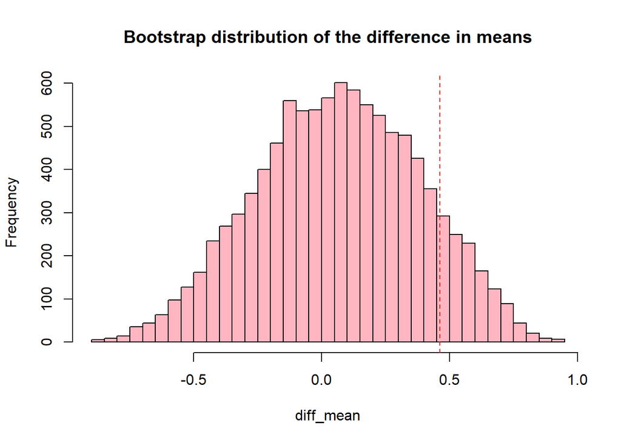

```r
hist(diff_mean,breaks=50,main = "Bootstrap distribution of the difference in means",col = 'light pink')
abline(v = mean(Year2010.sample) - mean(Year2022.sample), col = "red", lty = 2)
```

```r
data <-  read.csv("spotify_cleaned.csv")
```

Data Science Questions: Are the variables contributing for predicting “popularity” of the songs is same for different genres?

Create a new variable named “Valence_C”.

```r
data$Valence_C <- rep(0,nrow(data))

data1 <- within(data, {
  Valence_C[valence>=0.8 & valence<=1] <- "more positive"
  Valence_C[valence>=0.5 & valence<0.8] <- "moderate"
  Valence_C[valence<=0.499] <- "more negative"
})
head(data1)
```

```
##   X                                                  name           artist
## 1 1 I Don't Care (with Justin Bieber) - Loud Luxury Remix       Ed Sheeran
## 2 2                       Memories - Dillon Francis Remix         Maroon 5
## 3 3                       All the Time - Don Diablo Remix     Zara Larsson
## 4 4                     Call You Mine - Keanu Silva Remix The Chainsmokers
## 5 5               Someone You Loved - Future Humans Remix    Lewis Capaldi
## 6 6     Beautiful People (feat. Khalid) - Jack Wins Remix       Ed Sheeran
##   popularity year genre  subgenre danceability energy key loudness mode
## 1         66 2019   pop dance pop        0.748  0.916   6   -2.634    1
## 2         67 2019   pop dance pop        0.726  0.815  11   -4.969    1
## 3         70 2019   pop dance pop        0.675  0.931   1   -3.432    0
## 4         60 2019   pop dance pop        0.718  0.930   7   -3.778    1
## 5         69 2019   pop dance pop        0.650  0.833   1   -4.672    1
## 6         67 2019   pop dance pop        0.675  0.919   8   -5.385    1
##   speechiness acousticness instrumantalness liveness valence   tempo duration
## 1      0.0583       0.1020         0.00e+00   0.0653   0.518 122.036   194754
## 2      0.0373       0.0724         4.21e-03   0.3570   0.693  99.972   162600
## 3      0.0742       0.0794         2.33e-05   0.1100   0.613 124.008   176616
## 4      0.1020       0.0287         9.43e-06   0.2040   0.277 121.956   169093
## 5      0.0359       0.0803         0.00e+00   0.0833   0.725 123.976   189052
## 6      0.1270       0.0799         0.00e+00   0.1430   0.585 124.982   163049
##       Valence_C
## 1      moderate
## 2      moderate
## 3      moderate
## 4 more negative
## 5      moderate
## 6      moderate
```

Fit multiple linear regression models separately for different genres.

```r
set.seed(12)
library(caret)
library(tidyverse)
```

```r
pop <- data1[data1$genre=="pop",]
edm <- data1[data1$genre=="edm",]
```

```r
names(pop)
```

```
##  [1] "X"                "name"             "artist"           "popularity"
##  [5] "year"             "genre"            "subgenre"         "danceability"
##  [9] "energy"           "key"              "loudness"         "mode"
## [13] "speechiness"      "acousticness"     "instrumantalness" "liveness"
## [17] "valence"          "tempo"            "duration"         "Valence_C"
```

```r
training_samples <- pop$popularity %>%
  createDataPartition(p=0.8, list=FALSE)

train <- pop[training_samples, ]
test <- pop[-training_samples, ]
dim(train)
```

```
## [1] 4407   20
```

Fit the FULL linear regression model.

```r
fit1 <- lm(popularity ~ danceability + energy + loudness + speechiness + acousticness + instrumantalness + liveness + valence + tempo +Valence_C, data = train)
summary(fit1)
```

```
##
## Call:
## lm(formula = popularity ~ danceability + energy + loudness +
##     speechiness + acousticness + instrumantalness + liveness +
##     valence + tempo + Valence_C, data = train)
##
## Residuals:
##     Min      1Q  Median      3Q     Max
## -64.194 -17.056   4.545  19.186  58.333
##
## Coefficients:
##                          Estimate Std. Error t value Pr(>|t|)
## (Intercept)             74.966782   4.959693  15.115  < 2e-16 ***
## danceability            14.311075   3.227621   4.434 9.48e-06 ***
## energy                 -33.654892   3.451728  -9.750  < 2e-16 ***
## loudness                 2.548691   0.198625  12.832  < 2e-16 ***
## speechiness             22.378111   5.546528   4.035 5.56e-05 ***
## acousticness             1.132331   2.091348   0.541   0.5882
## instrumantalness       -10.358720   2.168184  -4.778 1.83e-06 ***
## liveness                 0.372393   2.730148   0.136   0.8915
## valence                  4.192508   3.821088   1.097   0.2726
## tempo                    0.002425   0.015471   0.157   0.8754
## Valence_Cmore negative   0.246728   1.379914   0.179   0.8581
## Valence_Cmore positive  -4.052253   1.548440  -2.617   0.0089 **
## ---
## Signif. codes:  0 '***' 0.001 '**' 0.01 '*' 0.05 '.' 0.1 ' ' 1
##
## Residual standard error: 24.18 on 4395 degrees of freedom
## Multiple R-squared:  0.07447,    Adjusted R-squared:  0.07215
## F-statistic: 32.15 on 11 and 4395 DF,  p-value: < 2.2e-16
```

Remove insignificant variables.

```r
fit2 <- lm(popularity ~ danceability + energy + loudness + speechiness + instrumantalness + Valence_C, data = train)
summary(fit2)
```

```
##
## Call:
## lm(formula = popularity ~ danceability + energy + loudness +
##     speechiness + instrumantalness + Valence_C, data = train)
##
## Residuals:
##     Min      1Q  Median      3Q     Max
## -64.044 -17.094   4.524  19.181  58.725
##
## Coefficients:
##                        Estimate Std. Error t value Pr(>|t|)
## (Intercept)             77.8923     3.9773  19.584  < 2e-16 ***
## danceability            14.7807     3.0557   4.837 1.36e-06 ***
## energy                 -33.8176     3.0221 -11.190  < 2e-16 ***
## loudness                 2.5462     0.1982  12.844  < 2e-16 ***
## speechiness             23.0326     5.4536   4.223 2.46e-05 ***
## instrumantalness       -10.5435     2.1567  -4.889 1.05e-06 ***
## Valence_Cmore negative  -0.9738     0.8297  -1.174   0.2406
## Valence_Cmore positive  -3.0531     1.2655  -2.413   0.0159 *
## ---
## Signif. codes:  0 '***' 0.001 '**' 0.01 '*' 0.05 '.' 0.1 ' ' 1
##
## Residual standard error: 24.18 on 4399 degrees of freedom
## Multiple R-squared:  0.07414,    Adjusted R-squared:  0.07267
## F-statistic: 50.32 on 7 and 4399 DF,  p-value: < 2.2e-16
```

Check interactions.

```r
fit12 <- lm(popularity ~ (danceability+energy+loudness+speechiness+instrumantalness)^2, data=train)
summary(fit12)
```

```
##
## Call:
## lm(formula = popularity ~ (danceability + energy + loudness +
##     speechiness + instrumantalness)^2, data = train)
##
## Residuals:
##     Min      1Q  Median      3Q     Max
## -62.687 -16.864   4.522  19.050  53.836
##
## Coefficients:
##                               Estimate Std. Error t value Pr(>|t|)
## (Intercept)                   103.1230    14.9440   6.901 5.92e-12 ***
## danceability                   -5.9375    22.2770  -0.267 0.789844
## energy                        -72.3426    14.8384  -4.875 1.12e-06 ***
## loudness                        3.8407     0.9789   3.924 8.85e-05 ***
## speechiness                    28.1324    60.8885   0.462 0.644082
## instrumantalness              -70.0682    18.7063  -3.746 0.000182 ***
## danceability:energy            41.5464    21.7212   1.913 0.055850 .
## danceability:loudness           0.3138     1.4425   0.218 0.827802
## danceability:speechiness      -74.1727    42.3132  -1.753 0.079681 .
## danceability:instrumantalness  -1.8488    14.8859  -0.124 0.901163
## energy:loudness                -1.2025     0.6406  -1.877 0.060553 .
## energy:speechiness             21.8262    47.0904   0.463 0.643032
## energy:instrumantalness        29.7824    13.9461   2.136 0.032772 *
## loudness:speechiness           -4.4678     3.3171  -1.347 0.178077
## loudness:instrumantalness      -4.5224     0.8919  -5.071 4.12e-07 ***
## speechiness:instrumantalness   57.2961    62.7741   0.913 0.361432
## ---
## Signif. codes:  0 '***' 0.001 '**' 0.01 '*' 0.05 '.' 0.1 ' ' 1
##
## Residual standard error: 24.09 on 4391 degrees of freedom
## Multiple R-squared:  0.08224,    Adjusted R-squared:  0.0791
## F-statistic: 26.23 on 15 and 4391 DF,  p-value: < 2.2e-16
```

```r
fit3 <- lm(popularity~danceability+energy+loudness+speechiness+instrumantalness+energy*loudness+loudness*instrumantalness,data=train)
summary(fit3)
```

```
##
## Call:
## lm(formula = popularity ~ danceability + energy + loudness +
##     speechiness + instrumantalness + energy * loudness + loudness *
##     instrumantalness, data = train)
##
## Residuals:
##     Min      1Q  Median      3Q     Max
## -62.679 -16.902   4.628  19.004  51.384
##
## Coefficients:
##                           Estimate Std. Error t value Pr(>|t|)
## (Intercept)                85.3323     4.8193  17.706  < 2e-16 ***
## danceability               13.6163     2.8745   4.737 2.24e-06 ***
## energy                    -42.2346     5.2307  -8.074 8.68e-16 ***
## loudness                    3.5558     0.4316   8.239 2.26e-16 ***
## speechiness                23.9101     5.4301   4.403 1.09e-05 ***
## instrumantalness          -36.5057     5.5841  -6.537 6.97e-11 ***
## energy:loudness            -1.1351     0.6160  -1.843   0.0654 .
## loudness:instrumantalness  -3.1077     0.6226  -4.991 6.22e-07 ***
## ---
## Signif. codes:  0 '***' 0.001 '**' 0.01 '*' 0.05 '.' 0.1 ' ' 1
##
## Residual standard error: 24.12 on 4399 degrees of freedom
## Multiple R-squared:  0.07821,    Adjusted R-squared:  0.07674
## F-statistic: 53.32 on 7 and 4399 DF,  p-value: < 2.2e-16
```

Make Predictions

```r
pred1 <- fit1 %>% predict(test)
p1 = data.frame(
  RMSE=RMSE(pred1,test$popularity),
  R2=R2(pred1,test$popularity)
)

pred2 <- fit2 %>% predict(test)
p2 <- data.frame(
  RMSE=RMSE(pred2,test$popularity),
  R2=R2(pred2,test$popularity)
)

pred3 <- fit3 %>% predict(test)
p3 <- data.frame(
  RMSE=RMSE(pred3,test$popularity),
  R2=R2(pred3,test$popularity)
)
```

```r
summary(fit1)$fstatistic[1]
```

```
##   value
## 32.1482
```

```r
summary(fit1)$adj.r.squared
```

```
## [1] 0.07215349
```

```r
summary(fit1)$sigma #RSE
```

```
## [1] 24.18283
```

```r
all=rbind(p1,p2,p3)
all=cbind(all,c(summary(fit1)$fstatistic[1],summary(fit2)$fstatistic[1],summary(fit3)$fstatistic[1]))
all=cbind(all,c(summary(fit1)$adj.r.squared,summary(fit2)$adj.r.squared,summary(fit3)$adj.r.squared))
all=cbind(all,c(summary(fit1)$sigma,summary(fit2)$sigma,summary(fit3)$sigma))

all=cbind(all,c("fit1","fit2","fit3"))
colnames(all)[c(3,4,5,6)]<-c("F stat","Adj R 2","RSE","models")
all
```

```
##       RMSE         R2   F stat    Adj R 2      RSE models
## 1 24.56187 0.06293309 32.14820 0.07215349 24.18283   fit1
## 2 24.56240 0.06287795 50.32470 0.07266956 24.17610   fit2
## 3 24.48017 0.06916223 53.31969 0.07674341 24.12294   fit3
```

It turns out that fit3 is the best model.

Next we check the predictors for genres “EDM” and compared with “Pop”.

```r
training_samples <- edm$popularity %>%
  createDataPartition(p=0.8,list = FALSE)

train <- edm[training_samples,]
test <- edm[-training_samples,]
dim(train)
```

```
## [1] 4836   20
```

```r
names(train)
```

```
##  [1] "X"                "name"             "artist"           "popularity"
##  [5] "year"             "genre"            "subgenre"         "danceability"
##  [9] "energy"           "key"              "loudness"         "mode"
## [13] "speechiness"      "acousticness"     "instrumantalness" "liveness"
## [17] "valence"          "tempo"            "duration"         "Valence_C"
```

Fit FULL linear regression model for EDM.

```r
fit11 <- lm(popularity ~ danceability+energy+loudness+speechiness+acousticness+instrumantalness+liveness+valence+tempo+Valence_C, data = train)
summary(fit11)
```

```
##
## Call:
## lm(formula = popularity ~ danceability + energy + loudness +
##     speechiness + acousticness + instrumantalness + liveness +
##     valence + tempo + Valence_C, data = train)
##
## Residuals:
##     Min      1Q  Median      3Q     Max
## -60.222 -17.139   1.452  16.119  60.599
##
## Coefficients:
##                         Estimate Std. Error t value Pr(>|t|)
## (Intercept)             69.80804    5.19775  13.430  < 2e-16 ***
## danceability            -1.61857    2.98997  -0.541   0.5883
## energy                 -22.54855    3.39266  -6.646 3.34e-11 ***
## loudness                 1.05649    0.19034   5.551 3.00e-08 ***
## speechiness             -5.85242    4.54543  -1.288   0.1980
## acousticness            18.75716    2.42862   7.723 1.37e-14 ***
## instrumantalness       -11.67195    1.11720 -10.448  < 2e-16 ***
## liveness                -0.50596    1.91175  -0.265   0.7913
## valence                  3.42872    2.88262   1.189   0.2343
## tempo                   -0.06207    0.02144  -2.895   0.0038 **
## Valence_Cmore negative  -3.01397    1.23370  -2.443   0.0146 *
## Valence_Cmore positive  -0.09883    1.62645  -0.061   0.9515
## ---
## Signif. codes:  0 '***' 0.001 '**' 0.01 '*' 0.05 '.' 0.1 ' ' 1
##
## Residual standard error: 22 on 4824 degrees of freedom
## Multiple R-squared:  0.09797,    Adjusted R-squared:  0.09592
## F-statistic: 47.63 on 11 and 4824 DF,  p-value: < 2.2e-16
```

Remove insignificant variables.

```r
fit22 <- lm(popularity ~ energy+loudness+acousticness+instrumantalness+tempo+Valence_C,data=train)
summary(fit22)
```

```
##
## Call:
## lm(formula = popularity ~ energy + loudness + acousticness +
##     instrumantalness + tempo + Valence_C, data = train)
##
## Residuals:
##     Min      1Q  Median      3Q     Max
## -59.994 -17.040   1.451  16.197  60.350
##
## Coefficients:
##                         Estimate Std. Error t value Pr(>|t|)
## (Intercept)             70.63965    4.14229  17.053  < 2e-16 ***
## energy                 -22.92205    3.34518  -6.852 8.18e-12 ***
## loudness                 1.08253    0.18969   5.707 1.22e-08 ***
## acousticness            18.71702    2.40287   7.789 8.18e-15 ***
## instrumantalness       -11.83083    1.07050 -11.052  < 2e-16 ***
## tempo                   -0.06221    0.02095  -2.969  0.00301 **
## Valence_Cmore negative  -4.03112    0.72655  -5.548 3.04e-08 ***
## Valence_Cmore positive   0.72013    1.45498   0.495  0.62066
## ---
## Signif. codes:  0 '***' 0.001 '**' 0.01 '*' 0.05 '.' 0.1 ' ' 1
##
## Residual standard error: 22 on 4828 degrees of freedom
## Multiple R-squared:  0.09733,    Adjusted R-squared:  0.09602
## F-statistic: 74.37 on 7 and 4828 DF,  p-value: < 2.2e-16
```

Check interactions.

```r
fit12 <- lm(popularity~(energy+loudness+acousticness+instrumantalness+tempo)^2,data = train)
summary(fit12)
```

```
##
## Call:
## lm(formula = popularity ~ (energy + loudness + acousticness +
##     instrumantalness + tempo)^2, data = train)
##
## Residuals:
##     Min      1Q  Median      3Q     Max
## -61.181 -17.354   1.618  15.903  61.269
##
## Coefficients:
##                                 Estimate Std. Error t value Pr(>|t|)
## (Intercept)                    174.99957   29.15749   6.002 2.09e-09 ***
## energy                        -126.28142   28.83189  -4.380 1.21e-05 ***
## loudness                         5.00799    1.74073   2.877 0.004033 **
## acousticness                   -15.48766   22.37814  -0.692 0.488915
## instrumantalness               -36.98138   14.61259  -2.531 0.011412 *
## tempo                           -0.89089    0.22725  -3.920 8.97e-05 ***
## energy:loudness                  0.02925    0.87817   0.033 0.973426
## energy:acousticness             -4.79823   18.10678  -0.265 0.791023
## energy:instrumantalness         26.52900    9.93878   2.669 0.007628 **
## energy:tempo                     0.79113    0.22253   3.555 0.000381 ***
## loudness:acousticness            1.82139    1.16484   1.564 0.117969
## loudness:instrumantalness       -1.08406    0.51276  -2.114 0.034553 *
## loudness:tempo                  -0.03137    0.01284  -2.443 0.014613 *
## acousticness:instrumantalness    5.23843    9.01513   0.581 0.561220
## acousticness:tempo               0.41017    0.11723   3.499 0.000472 ***
## instrumantalness:tempo          -0.02880    0.08831  -0.326 0.744372
## ---
## Signif. codes:  0 '***' 0.001 '**' 0.01 '*' 0.05 '.' 0.1 ' ' 1
##
## Residual standard error: 22.01 on 4820 degrees of freedom
## Multiple R-squared:  0.09745,    Adjusted R-squared:  0.09464
## F-statistic:  34.7 on 15 and 4820 DF,  p-value: < 2.2e-16
```

```r
fit33 <- lm(popularity~energy+loudness+acousticness+instrumantalness+tempo+energy*instrumantalness+energy*tempo+loudness*acousticness+loudness*instrumantalness+loudness*tempo+acousticness*tempo,data = train)
summary(fit33)
```

```
##
## Call:
## lm(formula = popularity ~ energy + loudness + acousticness +
##     instrumantalness + tempo + energy * instrumantalness + energy *
##     tempo + loudness * acousticness + loudness * instrumantalness +
##     loudness * tempo + acousticness * tempo, data = train)
##
## Residuals:
##     Min      1Q  Median      3Q     Max
## -60.852 -17.348   1.649  15.852  61.511
##
## Coefficients:
##                             Estimate Std. Error t value Pr(>|t|)
## (Intercept)                173.93172   27.04614   6.431 1.39e-10 ***
## energy                    -124.98282   26.31185  -4.750 2.09e-06 ***
## loudness                     4.94943    1.52289   3.250 0.001162 **
## acousticness               -20.87972   15.32116  -1.363 0.173008
## instrumantalness           -39.70270    9.87629  -4.020 5.91e-05 ***
## tempo                       -0.87870    0.21524  -4.082 4.53e-05 ***
## energy:instrumantalness     25.38726    9.21056   2.756 0.005868 **
## energy:tempo                 0.77807    0.20934   3.717 0.000204 ***
## loudness:acousticness        1.40103    0.64173   2.183 0.029070 *
## loudness:instrumantalness   -1.13734    0.50221  -2.265 0.023578 *
## loudness:tempo              -0.03033    0.01197  -2.535 0.011286 *
## acousticness:tempo           0.41191    0.11624   3.544 0.000399 ***
## ---
## Signif. codes:  0 '***' 0.001 '**' 0.01 '*' 0.05 '.' 0.1 ' ' 1
##
## Residual standard error: 22 on 4824 degrees of freedom
## Multiple R-squared:  0.09737,    Adjusted R-squared:  0.09531
## F-statistic: 47.31 on 11 and 4824 DF,  p-value: < 2.2e-16
```

Make predictions

```r
pred11 <- fit11 %>% predict(test)
p11=data.frame(
  RMSE=RMSE(pred11,test$popularity),
  R2=R2(pred11,test$popularity)
)

pred22 <- fit22 %>% predict(test)
p22=data.frame(
  RMSE=RMSE(pred22,test$popularity),
  R2=R2(pred22,test$popularity)
)

pred33 <- fit33 %>% predict(test)
p33=data.frame(
  RMSE=RMSE(pred33,test$popularity),
  R2=R2(pred33,test$popularity)
)
```

```r
all2=rbind(p11,p22,p33)
all2=cbind(all2,c(summary(fit11)$fstatistic[1],summary(fit22)$fstatistic[1],summary(fit33)$fstatistic[1]))
all2=cbind(all2,c(summary(fit11)$adj.r.squared,summary(fit22)$adj.r.squared,summary(fit33)$adj.r.squared))
all2=cbind(all2,c(summary(fit11)$sigma,summary(fit22)$sigma,summary(fit33)$sigma))

all2=cbind(all2,c("fit11","fit22","fit33"))
colnames(all2)[c(3,4,5,6)] <- c("F stat","Adj R 2","RSE","models")
all2
```

```
##       RMSE         R2   F stat    Adj R 2      RSE models
## 1 22.32606 0.07767128 47.63290 0.09591728 21.99751  fit11
## 2 22.32488 0.07775583 74.37116 0.09602481 21.99620  fit22
## 3 22.26614 0.08191485 47.30527 0.09530761 22.00492  fit33
```

It turns out that fit33j is the best model.